# Step 4: Feature-wise catch22 ROI Analysis

## Cross-validated SVM classification

### 10-fold cross-validated linear SVM

We can implement 10-fold cross-validation (CV) with the `caret` package.

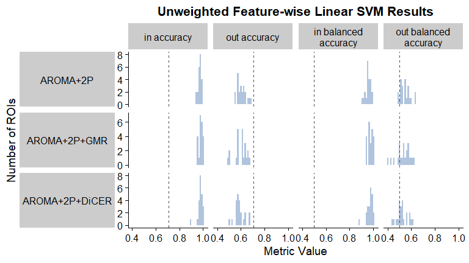

### 10-fold cross-validated linear SVM with inverse probability weighting

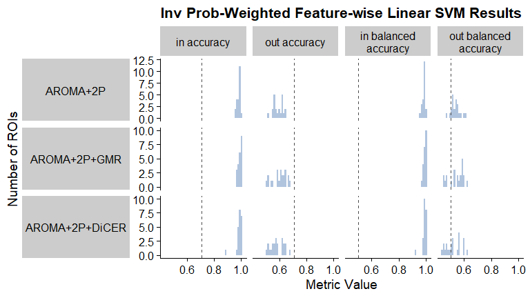

Surprisingly, incorporating inverse probability weighting has minimal impact when it comes to the ten-fold cross-validated SVM. Of note, the in-sample and cross-validated SVM were both run with kernlab::ksvm using default parameters.

### 10-fold cross-validated linear SVM with SMOTE

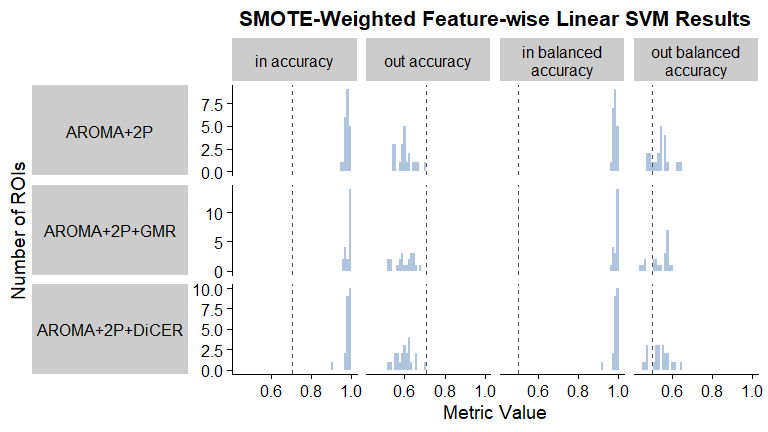

## Model-free shuffle null distribution

### Generating null distributions from model-free shuffles

This first model-free shuffles method is borrowed from Trent’s implementation in theft. With this method, the input class labels (Schz or Control) are randomly shuffled N times, and for each iteration, the classification accuracy and balanced accuracy are calculated. This yields a null distribution of accuracies and balanced accuracies, circumventing the need for running any classification algorithms across iterations.

Here, I’ve run 1,000,000 iterations of the model-free shuffle, generating 1,000,000 null values for Accuracy and Balanced Accuracy, respectively. Since this method is independent of brain region, the same null distribution can be used to compare with each brain region separately.

### Unweighted linear SVM

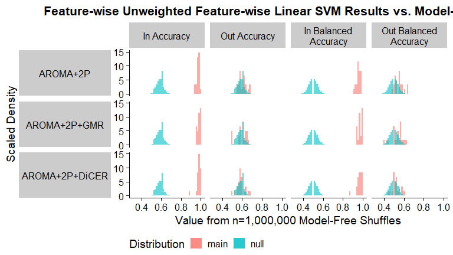

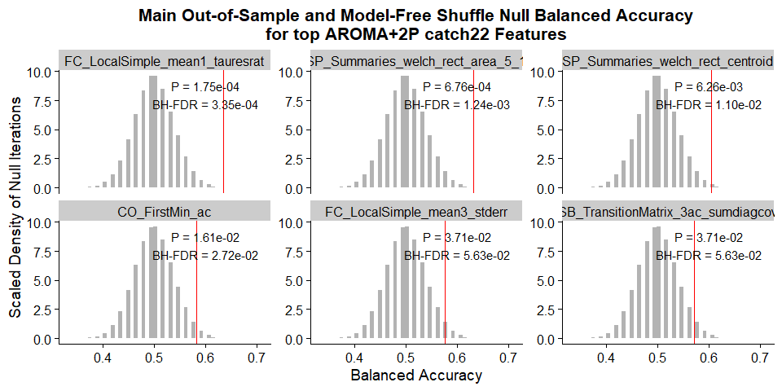

| Noise_Proc | Sample_Type | num_sig_acc | num_sig_acc_fdr | num_sig_bacc | num_sig_bacc_fdr |
| --- | --- | --- | --- | --- | --- |
| AROMA+2P | In-sample | 22 | 22 | 22 | 22 |
| AROMA+2P | Out-of-sample | 5 | 3 | 7 | 4 |
| AROMA+2P+GMR | In-sample | 22 | 22 | 22 | 22 |
| AROMA+2P+GMR | Out-of-sample | 6 | 3 | 8 | 4 |
| AROMA+2P+DiCER | In-sample | 22 | 22 | 22 | 22 |
| AROMA+2P+DiCER | Out-of-sample | 3 | 2 | 4 | 4 |

This table summarises the number of ROIs for which raw accuracy or balanced accuracy is significantly greater than the model-free shuffle null distribution, both before and after adjusting for multiple comparisons with BH-FDR.